# Semi-supervised Learning with Convolutional Neural Network for Image Classification

Appliaction to CT Images

Haiyue Song, Han Ji

2023-05-15

# Why We Need Semi-Supervised Learning (SSL)?

Machine learning is a powerful tool for big, complex data, and it generally falls into two categories: supervised and unsupervised learning. **These two categories seem to fit all types of problems, so why we need semi-supervised learning (SSL)?** Before introducing SSL, we first review supervised and unsupervised learning.

Supervised learning algorithms are trained on labeled data, meaning that both input and output data are provided to the model for learning. We denote this collection of labeled data points $D_L$ = $(x_i, y_i), \,i = 1, …, N$. Usually we assume there is an underlying relationship between Y and X as $Y = f(X) + \epsilon$. The algorithms try to capture this relationship $f$ and provide an estimate $\hat{f}$. The aim of the training step is to minimize
$$L =
\frac{1}{N}\sum^N_{i=1}l(\hat{f}(x_i),\,y_i), \text{ where } l \text{ is
the loss function.}$$
The estimated relationship $\hat{f}$ is then used to predict the output for new, unseen data (van Engelen & Hoos, 2020).

Unsupervised learning algorithms, on the other hand, deal with unlabeled data and primarily focus on identifying patterns or clusters within the data (van Engelen & Hoos, 2020; James et al., 2021). Here we only have a set of features $D_U$ = $x_i, \,i = 1, …, N$. Since we don’t have an associated label, the algorithm aims to generate artificial labels to summarize the interesting pattern in the data, and the objective function would focus on these generated labels. If we have $C = \{C_1, ..., C_k\}$ partitioning for k clusters, we aim to minimize
$$L =
\sum^k_{i=1}\sum_{x_m,\,x_n \in C_i}d(x_m, \,x_n), \text{ where } d
\text{ is the distance matric.}$$
In many real-world scenarios, however, data often come in a mix of labeled and unlabeled forms. In other words, we have sets $D_L$ and $D_U$ at the same time, and usually the number of data in $D_U$ is much larger. For example, in a medical study, many biopsy samples may be collected, but only a fraction are annotated by pathologists within a given period (Wenger et al., 2022).

In a financial context, an institution may know the credit scores of certain clients but needs to estimate for others based on their background information. Although we might have substantial information about the covariates, the outcome is not known for all individuals. In these cases, supervised learning methods may face limitations, while unsupervised model cannot perform the predictions we want. When the labeled observations are scarce, the supervised model built would bias towards these complete cases, potentially resulting in unsatisfactory performance. Thus, researchers come up with the idea of semi-supervised learning (SSL) that uses both labeled and unlabeled data.

# What is SSL?

As its name suggested, SSL is a combination of supervised learning and unsupervised learning, and it is usually used in classification problem. The general form of the objective function is written as a combination as well:
$$\min J=\min (\beta
J_{L}+\lambda J_{U}),\, \beta, \lambda \in [0,1]$$
Here $J$ is the overall loss, and $J_L$ and $J_U$ represents the loss function based on labeled set and features of all data. $\beta$ and $\lambda$ are the regularization parameter to control the effect of two loss function. If $\beta$ = 1 and $\lambda$ = 0, this becomes a supervised learning algorithm; if $\beta$ = 0 and $\lambda$ = 1, this becomes an unsupervised learning algorithm. Usually, $\beta$ = 1 is used (Ling et al., 2018; Wenger et al., 2022).

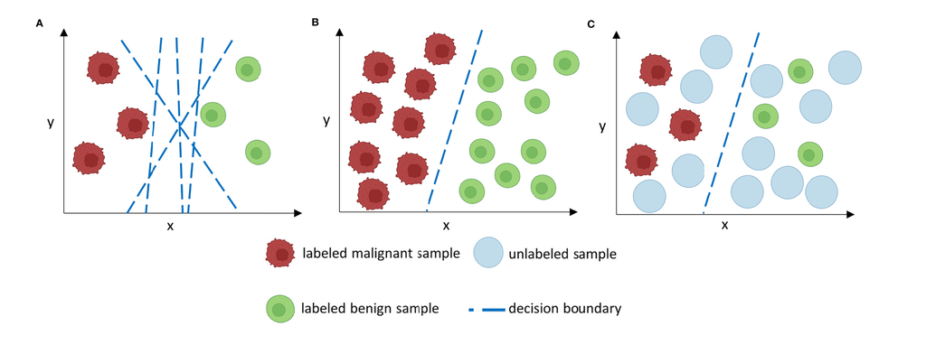

Example of semi-supervised learning from Eckardt et al. (2022)

Here we have a simple demonstration of samples with dichotomous outcome - benign and malignant cells - with two covariates x and y. In Part B, if we could know the labels of all samples, we would easily draw a decision boundary to separate these two groups. However, the true labels we observed are shown in Part A, where there are too many ways to draw a linear decision boundary. Most of these lines are not only inaccurate for the true labels but also vary too much. In Part C, we can first group all observations by x and y, and we can assign labels to the unlabeled data based on distribution of the true labels in this grouping. Ideally, we can get a more accurate and not varying decision boundary. This shows SSL can be more effective than the supervised learning only based on the complete cases.

# Self-Training

One of the most easily interpretable semi-supervised learning algorithm is self-training. It first trains a model on the labeled data and generates pseudo labels for the unlabeled data. We choose the most confident unlabeled points with their predicted labels into the training process, and we repeat this process until meeting a stopping criteria. For a dichotomous outcome and the model prediction is the probability being in label 1, these steps can be expressed as:

$$\begin{aligned}
\hat{f}_0 &= \text{arg}\min J_L = \text{arg}\min
\frac{1}{N}\sum^N_{i=1}l(\hat{f}_0(x_i),\,y_i) \\
\hat{y_i} &= I \{ \hat{f}_0(x_i) > 0.5 \} \text{ for } x_i \in
D_U \\
M &= \sum_{x_i \in D_U} I \{ \max\left(1-\hat{f}_0(x_i)
,\hat{f}_0(x_i)\right) > c \} \\
&\text{ where } c \in (0,1) \text{ is the confidence threshold}
\end{aligned}$$
We then could have a combination-form objective function to find the optimal $\hat{f}$ for iteration t:

$$\begin{aligned}
\hat{f}_t &= \text{arg}\min \{J_L + \lambda J_U\} \\
&= \text{arg}\min \{\frac{1}{N}\sum_{x_i \in D_L}l(\hat{f}_{t}(x_i,
\, y_i))\\
&+\lambda \frac{1}{M}\sum_{x_j\in D_U}l(\hat{f}_{t}(x_j, \,
\hat{y_j})\cdot I[\max\left(1-\hat{f}_{t-1}(x_i)
,\hat{f}_{t-1}(x_i)\right) > c] \} \\
& \text{where } t = 1, ..., T
\end{aligned}$$

After finding $\hat{f}_t$, we then repeat the steps for generating pseudo labels and selecting the most confident ones for the next iteration t+1, and their expressions should be similar to the ones we’ve shown in the initialization step above (Zhu, 2005).

# Assumptions of SSL

SSL is a powerful algorithm that utilizes the information from the unlabeled data. However, its performance is based on three strong assumption: **smoothness, low-density, manifold** (van Engelen & Hoos, 2020).

We first assume that the data points are close together in the input space should have the same labels. Thus, the change in labels given the input space should be smooth instead of stochastic. We secondly assume that the decision boundary should lie in a region where observed data points are few. In other words, the decision boundary should pass through the low-density region of observed data. This makes sense with the smoothness assumption: if the decision boundary is within a high-density region, many points with similar covariates may have different labels, which is against the smoothness assumption.

Lastly, we assume that data points lying on the same manifold have the same label, where manifold is the lower-dimensional substructures with high-density observed data compared to the high-dimensional input space. This helps us to determine the labels of the unlabeled data if we can determine the manifolds and the data points lie on these manifold.

Overall, these assumption can be generalized to the cluster assumption, and we do see many common points between these assumptions and clustering. For example, data points with similar covariates should be grouped into the same cluster, and we can use this similarity to re-explain our three main assumptions: points are close together are similar; points in high-density area are similar; points lie on the same manifold are similar. Thus, we see how strongly SSL is connected with the unsupervised learning. On the other hand, if we cannot cluster the data in a meaningful way, SSL cannot improve the performance of a supervised learning model (van Engelen & Hoos, 2020).

# What is Convolutional Neural Networks (CNNs)?

**Convolutional Neural Networks (CNNs) are a class of deep, feed-forward neural networks, most commonly applied in analyzing imaging data, especially for image recognition and classification.** They are explicitly designed to process pixel data and can take in an input image, assign importance (learnable weights and biases) to various aspects/objects in the image and be able to differentiate one from the other. The architecture of a CNN is designed to take the key information of the input image. This is achieved with local connections and tied weights followed by some form of pooling which results in translation invariant features. It is easier to train and have many fewer parameters than fully connected vanilla feed-forward neural networks.

## The Input Feature

Generally, the raw input image and the features of each hidden layer are represented by a 3D tensor $\textbf{X} \in R^{d_1 \times d_2 \times d_3}$. Here, the first two dimensions $d_1, d_2$ of $\textbf{X}$ represents spatial coordinates of an image while the third dimension $d_3$ indicates the number of channels. For instance, for the raw inputs, if the image has red, green and blue channels, then $d_3=3$. But for the hidden layers, $d_3$ can be much larger. Additionally, each channel is also called a feature map (Fan et al., 2019).

## The Architecture of CNNs

There are two key building blocks of CNNs, namely the convolutional layer (linear transforms) and the pooling layer (nonlinear gating). Besides, we also use fully-connected layers as building blocks in the last few layers of a CNN. We will introduce these layers separately as below.

### Convolutional Layer

A convolutional layer has the same functionality as the vanilla feed-forward nerual network $z^{(i)}=\sigma^{(i)}(W^{(i)}z^{(i-1)}+b^{(i)})$, where the input feature $\textbf{X} \in R^{d_1 \times d_2 \times d_3}$ goes through an affine transformation first and then an element-wise nonlinear activation. But the difference between a convolutional layer and the vanilla feed-forward network hidden layer lies in the specific form of the affine transformation.

A convolutional layer uses numbers of **filters** to extract local features from the previous input. To be specific, each filter is represented by a 3D tensor $\textbf{F}_k \in R^{w \times w \times d_3} \quad (1 \leq k \leq \tilde{d}_3)$, where $w$ is the size of the filter (usually small, e.g. 3, 5) and $\tilde{d}_3$ denotes the total number of filters. And $d_3$ here for the third dimension is equal to that of the input feature $\textbf{X}$. To be brief, one usually says that the filter has size $w \times w$. Each filter $\textbf{F}_k$ then convolves with the input feature $\textbf{X}$ to obtain one single feature map $\textbf{O}^k \in R^{(d_1-w+1)\times (d_1-w+1)}$, where
$$\textbf{O}^k_{ij}=<[\textbf{X}]_{ij},\textbf{F}_k>=\sum_{i'=1}^{w}
\sum_{j'=1}^{w} \sum_{l=1}^{d_3}
[\textbf{X}]_{i+i'-1,j+j'-1,l}[\textbf{F}_k]_{i',j',l},$$
which is a locally weighted average of $[\textbf{X}]_{ij}$ using weight $\textbf{F}_k$. From the expression above, we can see that every average is taken from a small patch of $\textbf{X}$ starting at location $(i,j)$. If we treat the 3D tensors $[\textbf{X}]_{ij}$ and $\textbf{F}_k$ as vectors, then each filter computes their inner product with a part of $\textbf{X}$ indexed by $i,j$. This process can be also viewed as convolution, which makes it so called convolutional layer and convolutional neural network. The resulted feature maps $\{\textbf{O}^k\}$ is then be pack into a 3D tensor $\textbf{O}$ with size $(d_1-w+1) \times (d_2-w+1) \times \tilde d_3$ where $\textbf{O}_{ijk}=[\textbf{O}^k]_{ij}$. Note that the parameters need to be optimized are the elements in $\{\textbf{F}_k\}_{k=1}^{\tilde d_3}$. The above process are then followed by nonlinear activation functions, such as ReLU.

The convolution operation and the activation function work together to extract features $\bf{\tilde X}$ from the input $bf{X}$, which functions in a way similar to the vanilla feed-forward neural network. But the difference, which is one of the most important characteristic of CNNs, is **weight sharing**. The filters $\textbf{F}_k$ are shared across all locations $(i,j)$. Besides, intuitively, each filter $\textbf{F}_k$ serves to extract features similar to $\textbf{F}_k$ as the inner product process mentioned above with concept of correlation.

### Pooling Layer

A pooling layer aggregates the information of nearby features into a single one. This is a downsampling process, which reduces the size of the features for subsequent layers and save the computation time and memory. To simplify the mathematical expression of pooling layer, we introduce the basic and common form of the pooling layer, which is composed of the $2\times 2$ max-pooling filter. The $2\times 2$ max-pooling filter calculates $\max \{X_{i,j,k},X_{i+1,j,k},X_{i,j+1,k},,X_{i+1,j+1,k}\}$, which is the maximum of the $2 \times 2$ neighborhood in the spatial coordinates. And the pooling is processed for each feature map $k$ (channel). A $2 \times 2$ max-pooling filter will result in an output of size $d_1/2 \times d_2/2 \times d_3$. Additionally, the pooling layer does not involve any parameters to optimize. It is designed to reduce redundancy because a small neighborhood around a location $(i,j)$ is likely to contain the same information.

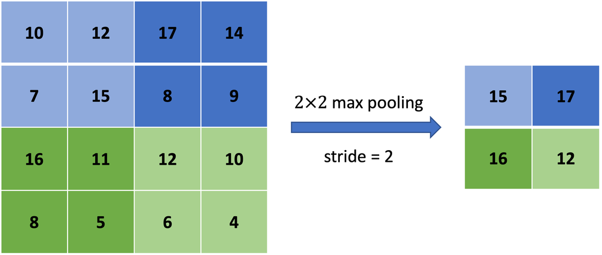

An example of Pooling Layer

### Fully-connected Layer

A fully-connected layer, also known as a linear layers, is typically placed at the end of the network, after the convolutional and pooling layers. The purpose of the fully-connected layer is to take the high-level features extracted by the preceding layers and perform classification or regression tasks based on those features. Each fully-connected layer has the mathematical form
$$z^{(i)}=\sigma^{(i)}(W^{(i)}z^{(i-1)}+b^{(i)}),$$
which is as the same functionality as the vanilla feed-forward neural network.

# Appliaction to CT Images

We will run the semi-supervised learning with CNN on a set of CT images. We set our baseline model as the CNN model fitting on the labeled data for comparison. We also fit a CNN model fitting on the whole training set with the true labels. The goal of classification is to identify if the image is scanned with contrast or without contrast.

## Data

We are going to analyze a small set of CT medical images data set from a cancer imaging archive with a categorical variable contrast and a continuous variable patient age . The data format is DICOM, and there are 100 files of 2D DICOM. Each DICOM represents the middle slice of the patient’s CT scan having 512*512 pixel dimensions. A sample with contrast and another without contrast are shown below.

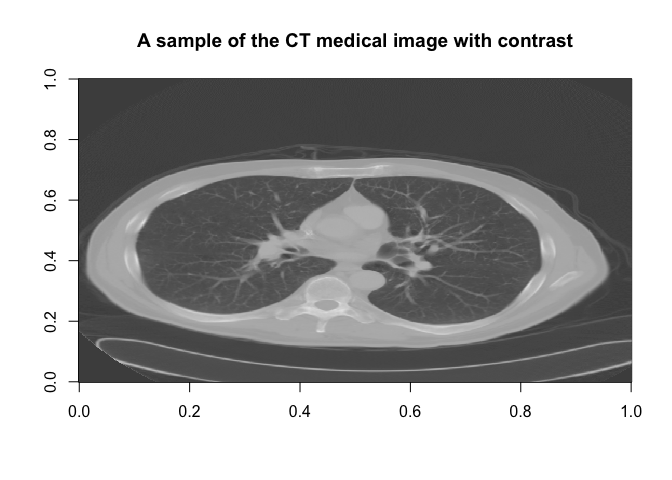

A sample of CT image with contrast

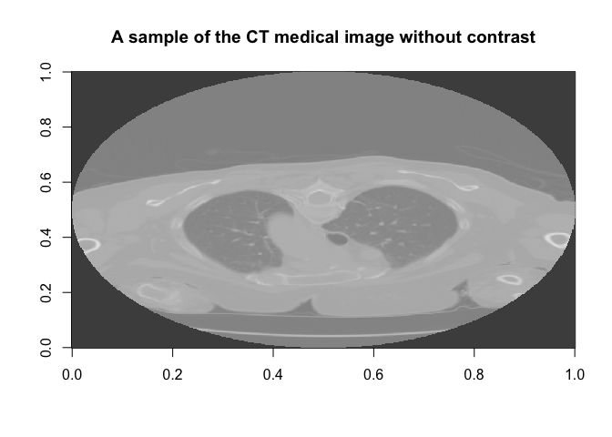

A sample of CT image without contrast

## Pre-processing and short exploratory data analysis

**For the features:** The original 2D scan has $512 \times 512$ pixel dimensions, which is memory-consuming. We used smoothing average to reduce the resolution of these 2D scans to $256 \times 256$ pixel dimensions. These 2D scans saved as arrays of gray colors.

**For the labels:** There are 100 scans in total, with 50 images with contrast and 50 images without contrast. Therefore the data is balanced.

**Train-test split for supervised learning:** We random selected 20 images (20%) as the test data set with 10 images with the label of `with contrast` and 10 images with the label of `without contrast`. The remaining 80 images are treated as the full training data. The training and test data are still balanced.

**Drop labels for SSL:** We randomly selected 40 images in total for dropping the labels with 20 images with the label of `with contrast` and 20 images with the label of `without contrast`. The remaining 40 scans in the training data with labels are still balanced and are treated as the training data for supervised learning with limited labeled images.

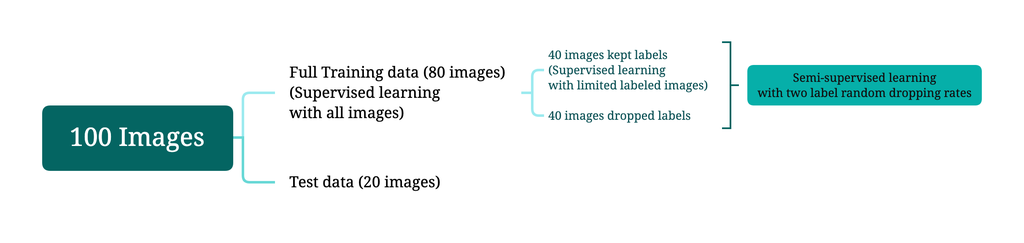

Structure of Train-Test Split and Label Dropping

**Normalization:** The scale of features are transformed to $(-1,1)$. We divide the pixel values by the maximum absolute value of pixel in the training dataset.

## The Architecture of CNN

The input layer has the shape $256 \times 256 \times 1$. Then, we set a convolutional layer having 8 filters with $3 \times 3$ size, and the activation function is ReLU; then we set a pooling layer with $3 \times 3$ max-pooling filters. Repeat these convolutional and pooling layer architecture for two more times. Next, after the flatten layer, we set a fully-connected dense layer with 64 neurons and ReLU activation function, and then we set a dropout layer with 0.2 dropout rate. Finally, the output layer with sigmoid function helps to complete the classification task.

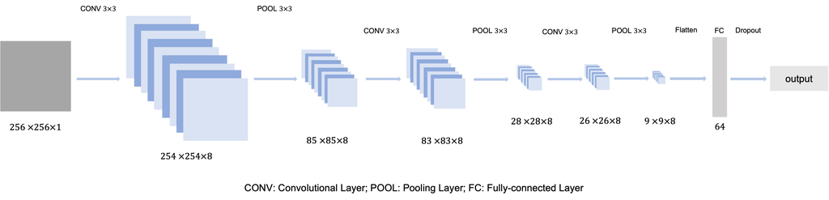

The Architecture of CNN

All the CNNs are built based on TensorFlow (Abadi et al., 2016).

## Supervised learning with limited labeled images

Evaluation Indicators of supervised learning model with 40 labeled images

|  | AUC | sensitivity | specificity | accuracy | precision |
| --- | --- | --- | --- | --- | --- |
| Training Data | 1.00 | 1.0 | 1.0 | 1.00 | 1.0000 |
| Test Data | 0.85 | 0.7 | 0.8 | 0.75 | 0.7778 |

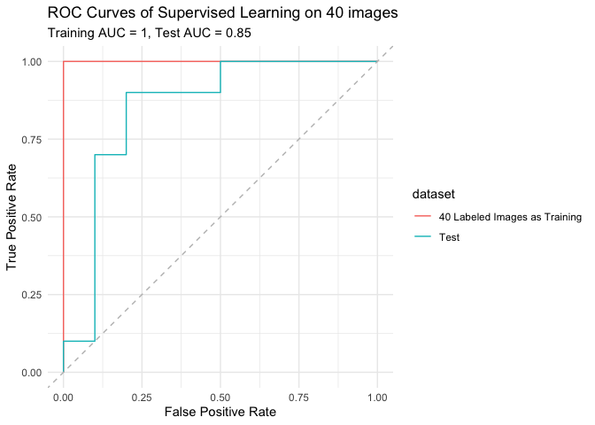

ROC Curves of Supervised Learning with 40 labeled images

## Semi-supervised learning

Then, based on the CNN trained on this limited 40 labeled images, we extend the model to SSL by self-training algorithm. We iteratively generates pseudo labels for the unlabeled images and choose the most confident unlabeled images with their predicted labels into the training process, and we repeat this process for ten times. The choice of ten times is to save the running time and reduce the memory consuming here. Additionally, the most confident means the predicted probability is greater than 0.95 or less than 0.05. We evaluate the SSL model on the test data set and the result is shown as below.

Evaluation Indicators of semi-supervised learning model with 40 labeled images

|  | AUC | sensitivity | specificity | accuracy | precision |
| --- | --- | --- | --- | --- | --- |
| Labeled Training Data | 1.00 | 1.0 | 1.0 | 1.0 | 1.000 |
| Test Data | 0.84 | 0.7 | 0.9 | 0.8 | 0.875 |

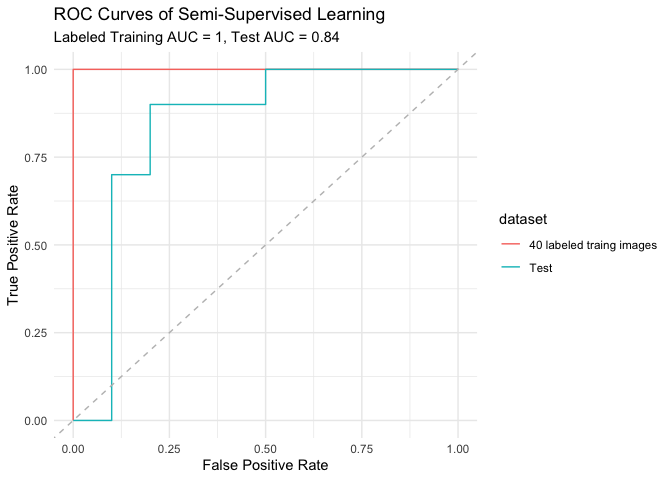

ROC Curves of Semi-Supervised Learning

## Supervised learning with all images

Finally, we train the CNN with the same architecture with all images in training dataset and show the performance. The AUC is 0.89, higher than the two models above. Compared to the SSL model, the full model doesn’t perform better for all metrics, but it seems to be better with a higher AUC overall.

Evaluation Indicators of the full supervised learning model

|  | AUC | sensitivity | specificity | accuracy | precision |
| --- | --- | --- | --- | --- | --- |
| Training Data | 0.95 | 0.875 | 0.9 | 0.8875 | 0.8974 |
| Test Data | 0.89 | 0.900 | 0.8 | 0.8500 | 0.8182 |

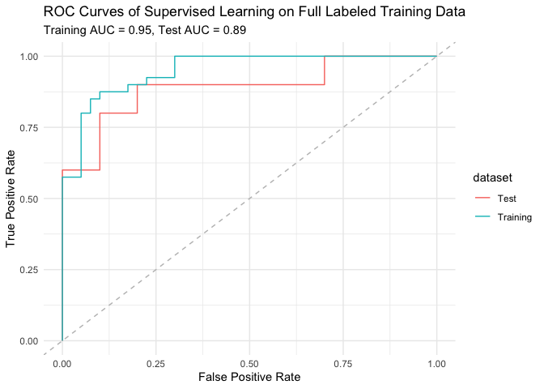

# Overall Comparisons

Comparison of Prediction on Test Data from Three Models

| Limited Labeled as Training | SSL | Fully Labeled as Training | True Label |
| --- | --- | --- | --- |
| 1 | 1 | 1 | 1 |
| 1 | 1 | 1 | 1 |
| 1 | 1 | 1 | 1 |
| 0 | 0 | 1 | 1 |
| 1 | 1 | 1 | 1 |
| 0 | 0 | 0 | 1 |
| 1 | 1 | 1 | 1 |
| 0 | 0 | 1 | 1 |
| 1 | 1 | 1 | 1 |
| 1 | 1 | 1 | 1 |
| 0 | 0 | 0 | 0 |
| 1 | 0 | 1 | 0 |
| 0 | 0 | 0 | 0 |
| 0 | 0 | 0 | 0 |
| 0 | 0 | 0 | 0 |
| 0 | 0 | 0 | 0 |
| 0 | 0 | 0 | 0 |
| 0 | 0 | 0 | 0 |
| 0 | 0 | 0 | 0 |
| 1 | 1 | 1 | 0 |

Comparison of Predicted Probability on Test Data from Three Models

| Limited Labeled as Training | SSL | Fully Labeled as Training | True Label |
| --- | --- | --- | --- |
| 0.8295 | 0.9957 | 0.8359 | 1 |
| 0.9981 | 0.9977 | 0.8333 | 1 |
| 0.9998 | 0.9986 | 0.9554 | 1 |
| 0.4694 | 0.0084 | 0.5529 | 1 |
| 0.9952 | 0.5670 | 0.8203 | 1 |
| 0.0003 | 0.0002 | 0.2205 | 1 |
| 1.0000 | 0.9992 | 0.9498 | 1 |
| 0.3121 | 0.0088 | 0.5266 | 1 |
| 0.7966 | 0.8832 | 0.7974 | 1 |
| 0.9999 | 0.9886 | 0.8779 | 1 |
| 0.0000 | 0.0006 | 0.0766 | 0 |
| 0.5938 | 0.2414 | 0.5338 | 0 |
| 0.1041 | 0.0001 | 0.2669 | 0 |
| 0.0002 | 0.0045 | 0.3773 | 0 |
| 0.0020 | 0.0001 | 0.3332 | 0 |
| 0.0000 | 0.0000 | 0.0175 | 0 |
| 0.0000 | 0.0000 | 0.1099 | 0 |
| 0.0002 | 0.0000 | 0.2984 | 0 |
| 0.0134 | 0.0002 | 0.3982 | 0 |
| 0.9999 | 1.0000 | 0.8097 | 0 |

Overall, we see that both supervised learning CNN model on the limited labeled and the SSL model seem to have overfitting issue as the AUC is 1. As the SSL model is based on the supervised model, we wouldn’t expect they have a big difference for prediction on the training set. However, the AUC of our full model is also close to one with good performance on the test set. This may imply that our CNN model can predict relatively well for the contrast label, so we don’t need to worry too much for the overfitting.

We see the supervised model with limited labels and the SSL model have nearly the same predictions on the test set, except the 12th one, and the SSL model predicts that one correctly. Thus, the SSL model is better than the supervised model with limited labels. When we check the predicted probability, we see the ones for the SSL model tend to more extreme (closer to 1 and 0), which is probably due to the self-learning process but also corresponds to the concept of low-density region. We see the change in probability for the SSL model is relatively larger when the probability is close to 0.5 in the limited label model. Thus, the SSL model seems to draw a decision boundary that makes a sharp differentiation between two labels.

In addition, we see the predicted probabilities of the limited label model and the full model are similar, and the ones that the full model performs better are mostly edge cases with probability close to 0.5. This implies that the the limited label model resembles the full model more than the SSL model. First, this implies the baseline model performs pretty well for this classification setting even with limited labels, and this may explain why we don’t see much improvement in SSL model. Second, this indicates a possible limitation of SSL with self-training that it may perform worse if the training process doesn’t go in the right direction and reinforce the error (survey). It should be important to test the basline supervised learning model on a validation set to see how much we can improve from it. Also, we may need to consider more advanced techniques beyond self-training.

# Reference

Abadi, M., Agarwal, A., Barham, P., Brevdo, E., Chen, Z., Citro, C., Corrado, G. S., Davis, A., Dean, J., Devin, M., Ghemawat, S., Goodfellow, I., Harp, A., Irving, G., Isard, M., Jia, Y., Jozefowicz, R., Kaiser, L., Kudlur, M., … Zheng, X. (2016). TensorFlow: Large-Scale Machine Learning on Heterogeneous Distributed Systems (arXiv:1603.04467). arXiv. https://doi.org/10.48550/arXiv.1603.04467

Albertina, B., Watson, M., Holback, C., Jarosz, R., Kirk, S., Lee, Y., … Lemmerman, J. (2016). Radiology Data from The Cancer Genome Atlas Lung Adenocarcinoma [TCGA-LUAD] collection. The Cancer Imaging Archive. http://doi.org/10.7937/K9/TCIA.2016.JGNIHEP5

Eckardt, J.-N., Bornhäuser, M., Wendt, K., & Middeke, J. M. (2022). Semi-supervised learning in cancer diagnostics. Frontiers in Oncology, 12, 960984. https://doi.org/10.3389/fonc.2022.960984

Fan, J., Ma, C., & Zhong, Y. (2019). A Selective Overview of Deep Learning (arXiv:1904.05526). arXiv. https://doi.org/10.48550/arXiv.1904.05526

James, G., Witten, D., Hastie, T., & Tibshirani, R. (2021). Unsupervised Learning. In G. James, D. Witten, T. Hastie, & R. Tibshirani (Eds.), An Introduction to Statistical Learning: With Applications in R (pp. 497–552). Springer US. https://doi.org/10.1007/978-1-0716-1418-1_12

Ling, Z., Li, X., Zou, W., & Guo, S. (2018). Semi-Supervised Learning via Convolutional Neural Network for Hyperspectral Image Classification. 2018 24th International Conference on Pattern Recognition (ICPR), 1–6. https://doi.org/10.1109/ICPR.2018.8545709\

van Engelen, J. E., & Hoos, H. H. (2020). A survey on semi-supervised learning. Machine Learning, 109(2), 373–440. https://doi.org/10.1007/s10994-019-05855-6

Wenger, K., Tirdad, K., Dela Cruz, A., Mari, A., Basheer, M., Kuk, C., van Rhijn, B. W. G., Zlotta, A. R., van der Kwast, T. H., & Sadeghian, A. (2022). A semi-supervised learning approach for bladder cancer grading. Machine Learning with Applications, 9, 100347. https://doi.org/10.1016/j.mlwa.2022.100347

Zhu, X. (Jerry). (2005). Semi-Supervised Learning Literature Survey [Technical Report]. University of Wisconsin-Madison Department of Computer Sciences. https://minds.wisconsin.edu/handle/1793/60444